# Statistiek I - Lab session 7

Dion Theodoridis (s3121534)

Generated on: Fri Mar 30 16:35:42 2018

# 1 Exercise 1

```r
download.file('http://www.let.rug.nl/wieling/Statistiek-I/full.rda','full.rda')
load('full.rda',verbose=T)
```

```
## Loading objects:
##   full
```

```r
library(effsize)
library(vcd)
library(psych)
head(full)
```

```
##   participant study edu_level gender hand instrument bl_edu l1cnt l2cnt
## 1           1  LING       VWO      F    R          Y      N     1     2
## 2          10 OTHER      HAVO      F    R          Y      N     2     2
## 3         100   CIS       VWO      F    R          N      N     1     2
## 4         101  LING       VWO      F    R          Y      N     1     1
## 5         102    IS       VWO      M    R          Y      N     1     1
## 6         103   CIS      HAVO      F    R          N      Y     1     1
##   age_listening age_reading age_speaking age_writing accent_strength_self
## 1             5          10           12          12                    5
## 2             7           7            7           7                    4
## 3            12          10           11          10                    6
## 4            10          10           10          10                    4
## 5            11          11           13          12                    8
## 6             9          10           10          10                    5
##   english_grade english_score_self english_score spk_frisian Q1 Q2 Q3 Q4
```

[output cut: 27 more lines]

```r
str(full)
```

```
## 'data.frame':    195 obs. of  60 variables:
##  $ participant         : int  1 10 100 101 102 103 104 105 106 107 ...
##  $ study               : Factor w/ 4 levels "CIS","IS","LING",..: 3 4 1 3 2 1 1 1 3 2 ...
##  $ edu_level           : Factor w/ 3 levels "HAVO","VWO","HBO": 2 1 2 2 2 1 2 2 2 2 ...
##  $ gender              : Factor w/ 2 levels "F","M": 1 1 1 1 2 1 1 2 1 2 ...
##  $ hand                : Factor w/ 2 levels "R","L": 1 1 1 1 1 1 1 1 2 1 ...
##  $ instrument          : Factor w/ 2 levels "Y","N": 1 1 2 1 1 2 1 1 1 2 ...
##  $ bl_edu              : Factor w/ 2 levels "Y","N": 2 2 2 2 2 1 2 2 2 2 ...
##  $ l1cnt               : num  1 2 1 1 1 1 1 1 1 1 ...
##  $ l2cnt               : num  2 2 2 1 1 1 2 2 2 1 ...
##  $ age_listening       : num  5 7 12 10 11 9 6 11 10 9 ...
##  $ age_reading         : num  10 7 10 10 11 10 9 12 11 6 ...
##  $ age_speaking        : num  12 7 11 10 13 10 9 12 11 11 ...
##  $ age_writing         : num  12 7 10 10 12 10 9 12 11 11 ...
##  $ accent_strength_self: num  5 4 6 4 8 5 4 3 7 5 ...
```

[output cut: 46 more lines]

```r
summary(full)
```

```
##   participant      study    edu_level  gender  hand    instrument bl_edu
##  Min.   :  1.0   CIS  :75   HAVO: 25   F:140   R:173   Y:118      Y: 19
##  1st Qu.: 49.5   IS   :39   VWO :135   M: 55   L: 22   N: 77      N:176
##  Median : 98.0   LING :58   HBO : 30
##  Mean   : 98.0   OTHER:23   NA's:  5
##  3rd Qu.:146.5
##  Max.   :195.0
##
##      l1cnt           l2cnt       age_listening     age_reading
##  Min.   :1.000   Min.   :0.000   Min.   : 0.000   Min.   : 4.000
##  1st Qu.:1.000   1st Qu.:1.000   1st Qu.: 7.000   1st Qu.: 9.000
##  Median :1.000   Median :2.000   Median : 9.000   Median :10.000
##  Mean   :1.092   Mean   :1.821   Mean   : 8.441   Mean   : 9.764
##  3rd Qu.:1.000   3rd Qu.:2.000   3rd Qu.:10.000   3rd Qu.:11.000
##  Max.   :3.000   Max.   :4.000   Max.   :14.000   Max.   :14.000
##
##   age_speaking     age_writing    accent_strength_self english_grade
##  Min.   : 0.000   Min.   : 6.00   Min.   :0.00         Min.   :5.000
##  1st Qu.: 9.000   1st Qu.:10.00   1st Qu.:3.50         1st Qu.:7.000
##  Median :10.000   Median :10.00   Median :5.00         Median :7.000
##  Mean   : 9.974   Mean   :10.42   Mean   :4.61         Mean   :7.211
##  3rd Qu.:11.000   3rd Qu.:12.00   3rd Qu.:6.00         3rd Qu.:8.000
##  Max.   :14.000   Max.   :15.00   Max.   :9.00         Max.   :9.500
##
##  english_score_self english_score    spk_frisian       Q1
##  Min.   : 3.250     Min.   : 4.300   Y: 20       Min.   :1.000
##  1st Qu.: 6.875     1st Qu.: 6.659   N:175       1st Qu.:6.000
##  Median : 7.750     Median : 7.269               Median :6.000
##  Mean   : 7.609     Mean   : 7.327               Mean   :6.333
##  3rd Qu.: 8.500     3rd Qu.: 8.060               3rd Qu.:7.000
##  Max.   :10.000     Max.   :10.000               Max.   :7.000
##
##        Q2              Q3              Q4              Q5
##  Min.   :3.000   Min.   :1.000   Min.   :1.000   Min.   :1.000
##  1st Qu.:6.000   1st Qu.:3.000   1st Qu.:3.000   1st Qu.:3.000
##  Median :6.000   Median :4.000   Median :5.000   Median :4.000
##  Mean   :6.164   Mean   :3.744   Mean   :4.349   Mean   :4.113
##  3rd Qu.:7.000   3rd Qu.:5.000   3rd Qu.:6.000   3rd Qu.:5.000
##  Max.   :7.000   Max.   :7.000   Max.   :7.000   Max.   :7.000
##
```

[output cut: 65 more lines]

```
##  Min.   :5.000   Min.   :5.000   Min.   :6.000   Min.   :4.00
##  1st Qu.:6.000   1st Qu.:6.000   1st Qu.:7.000   1st Qu.:6.00
##  Median :7.000   Median :7.000   Median :8.000   Median :6.00
##  Mean   :6.713   Mean   :6.682   Mean   :7.333   Mean   :6.45
##  3rd Qu.:8.000   3rd Qu.:7.000   3rd Qu.:8.000   3rd Qu.:7.00
##  Max.   :9.000   Max.   :9.000   Max.   :8.000   Max.   :8.00
##  NA's   :163     NA's   :178     NA's   :192
##   stats_choice
##  Min.   :1.000
##  1st Qu.:2.000
##  Median :3.000
##  Mean   :3.472
##  3rd Qu.:5.000
##  Max.   :7.000
##
```

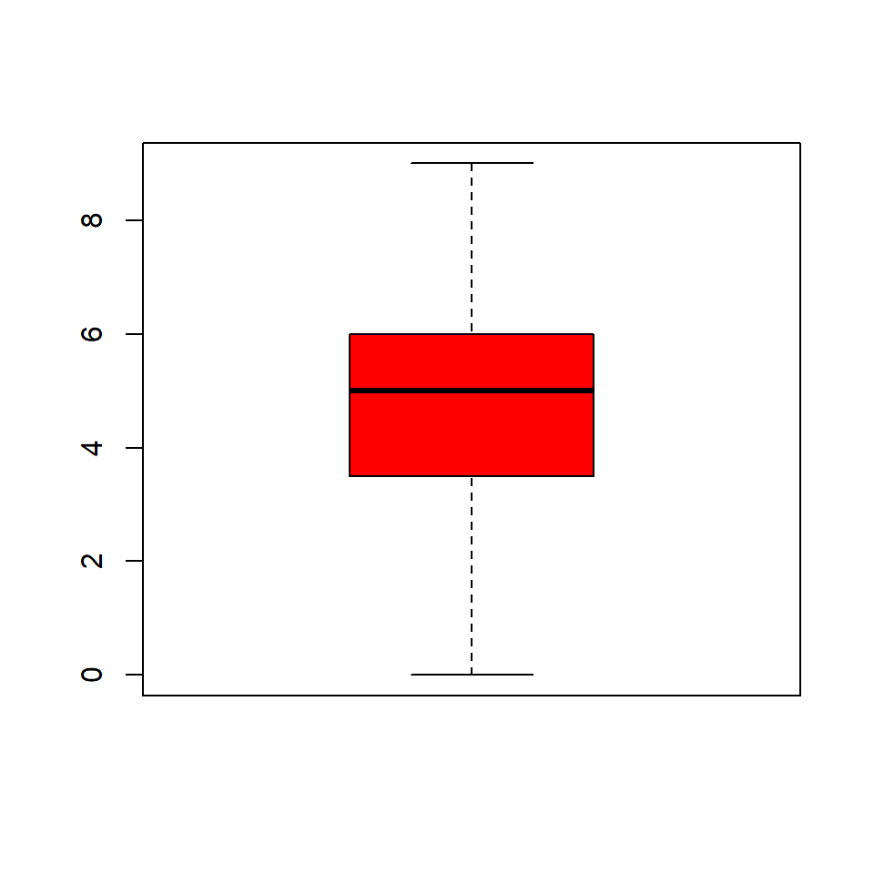

```r
boxplot(full$accent_strength_self, col="red")
```

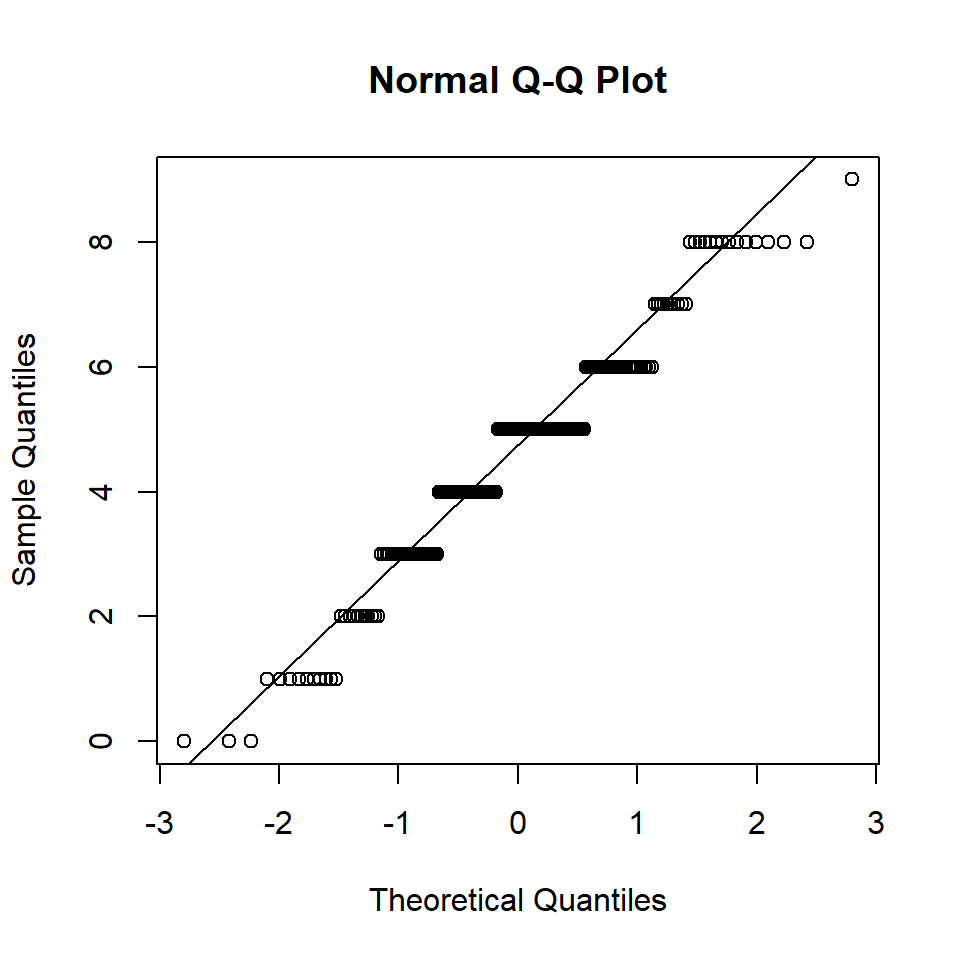

```r
qqnorm(full$accent_strength_self)
qqline(full$accent_strength_self)
```

```r
mean(full$accent_strength_self)
```

```
## [1] 4.610256
```

```r
sd(full$accent_strength_self)
```

```
## [1] 1.833789
```

```r
quantile(full$accent_strength_self)
```

```
##   0%  25%  50%  75% 100%
##  0.0  3.5  5.0  6.0  9.0
```

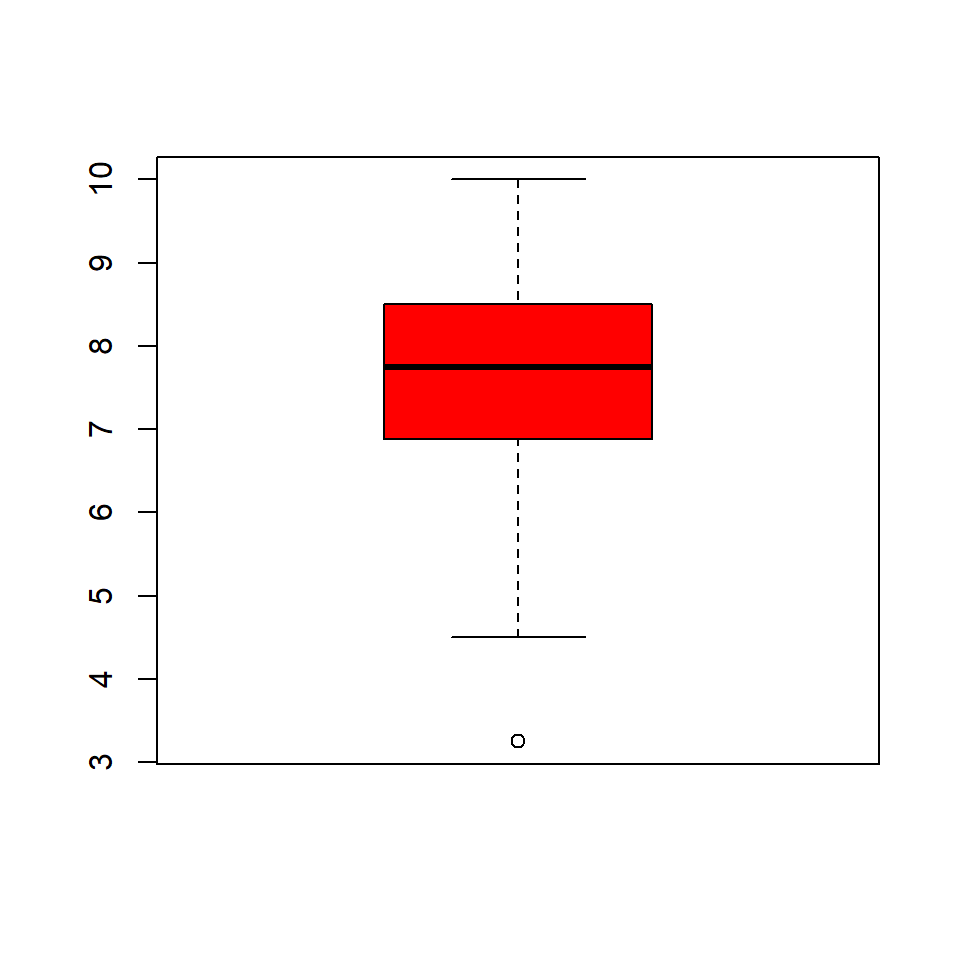

```r
boxplot(full$english_score_self, col="red")
```

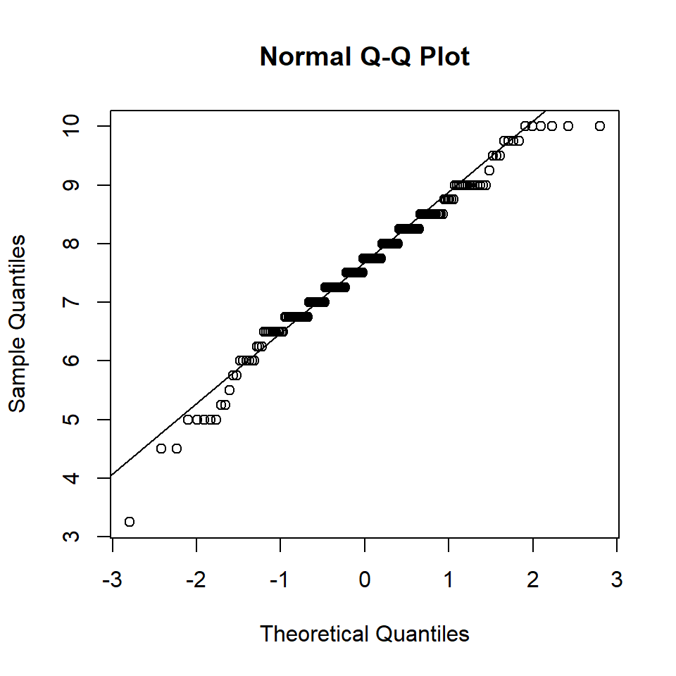

```r
qqnorm(full$english_score_self)
qqline(full$english_score_self)
```

```r
mean(full$english_score_self)
```

```
## [1] 7.608974
```

```r
sd(full$english_score_self)
```

```
## [1] 1.183808
```

```r
quantile(full$english_score_self)
```

```
##     0%    25%    50%    75%   100%
##  3.250  6.875  7.750  8.500 10.000
```

```r
table(full$spk_frisian)
```

```
##
##   Y   N
##  20 175
```

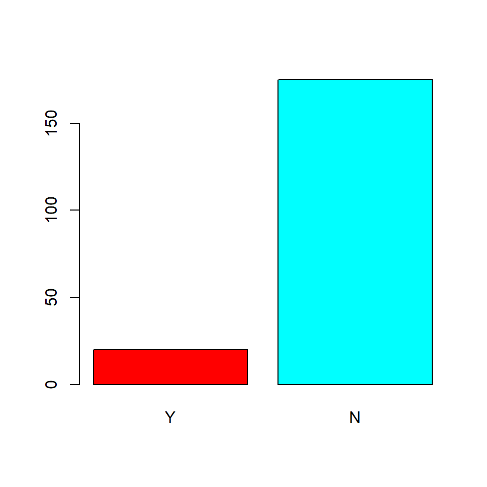

```r
barplot(table(full$spk_frisian), col=rainbow(2))
```

# 2 Exercise 2

```r
(tbl <- table(full$spk_frisian, full$study))
```

```
##
##     CIS IS LING OTHER
##   Y   8  2    6     4
##   N  67 37   52    19
```

```r
chisq.test(tbl)$expected
```

```
##
##           CIS IS      LING     OTHER
##   Y  7.692308  4  5.948718  2.358974
##   N 67.307692 35 52.051282 20.641026
```

```r
prop.table(tbl)
```

```
##
##            CIS         IS       LING      OTHER
##   Y 0.04102564 0.01025641 0.03076923 0.02051282
##   N 0.34358974 0.18974359 0.26666667 0.09743590
```

```r
prop.table(tbl, 1)
```

```
##
##           CIS        IS      LING     OTHER
##   Y 0.4000000 0.1000000 0.3000000 0.2000000
##   N 0.3828571 0.2114286 0.2971429 0.1085714
```

```r
prop.table(tbl, 2)
```

```
##
##            CIS         IS       LING      OTHER
##   Y 0.10666667 0.05128205 0.10344828 0.17391304
##   N 0.89333333 0.94871795 0.89655172 0.82608696
```

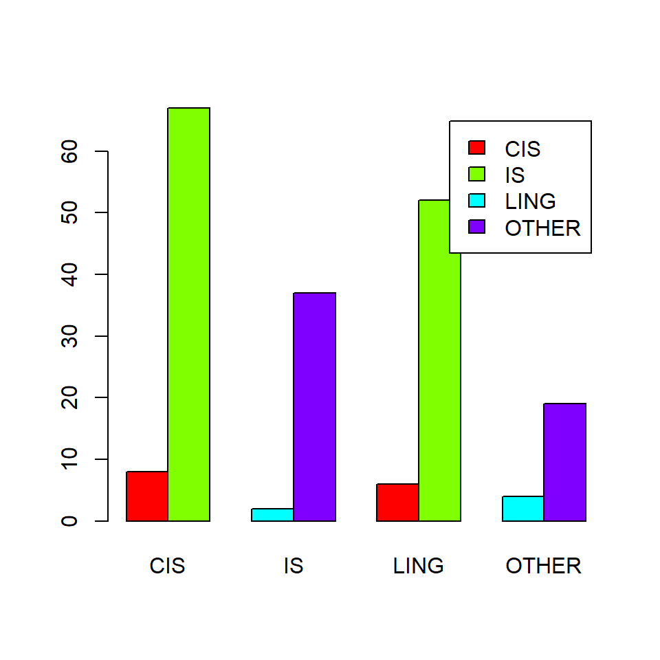

```r
barplot(tbl, legend = c("CIS", "IS", "LING", "OTHER"), beside = T, col=rainbow(4))
```

```r
fisher.test(tbl)
```

```
##
##  Fisher's Exact Test for Count Data
##
## data:  tbl
## p-value = 0.4832
## alternative hypothesis: two.sided
```

```r
assocstats(tbl)
```

```
##                     X^2 df P(> X^2)
## Likelihood Ratio 2.4302  3  0.48804
## Pearson          2.4005  3  0.49353
##
## Phi-Coefficient   : NA
## Contingency Coeff.: 0.11
## Cramer's V        : 0.111
```

```r
chisq.test(tbl)$stdres
```

```
##
##             CIS          IS        LING       OTHER
##   Y  0.14928401 -1.18019369  0.02647945  1.20089523
##   N -0.14928401  1.18019369 -0.02647945 -1.20089523
```

In this excercise will try to answer the following question:

Is there a relationship between speaking Frisian and study?

We will look at speaking Friasian (2 levels: yes, no) and study (4 levels: CIS, IS, LING, OTHER) of students. The sample exsists out of 195 students from the university of Groningen who follow the Statistics 1 course at the faculty of Arts who filled in a questionnaire from which the data was extracted. We are going to look if speaking Frisian and the study of the students are dependent.

$H_0$: Speaking Frisian and the study of the students are independent.  
$H_a$: Speaking Frisian and the study of the students are dependent.

$\alpha$ = 0.05

As both variables are nominal, and the expected frequency of each combination was’nt equal or greater than 5, we assessed the dependence of the two variables using the Fisher’s exact test.

p = 0.4832. Cramer’s V = 0.111

The p-value is higher than the significance level of 0.05 and therefor we do not reject $H_0$.

Conclusion:

# 3 Exercise 3

```r
table(full$spk_frisian)
```

```
##
##   Y   N
##  20 175
```

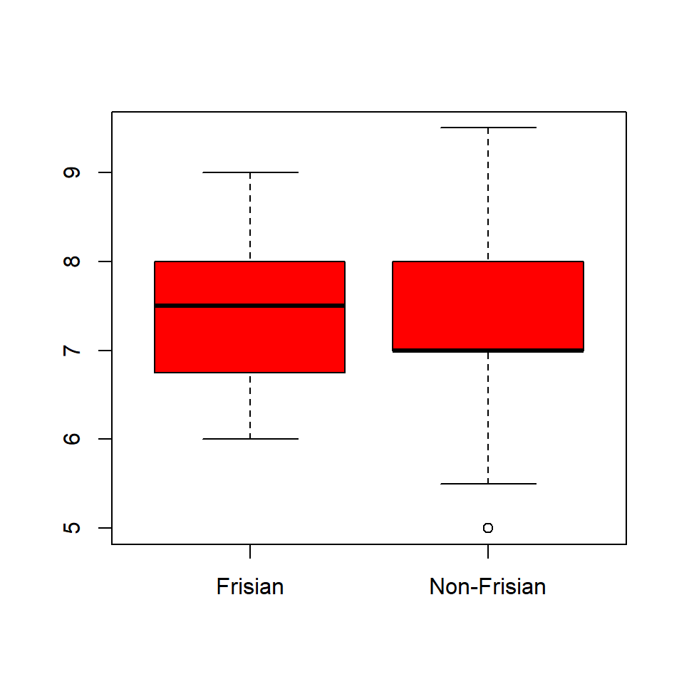

```r
boxplot(full[full$spk_frisian == "Y",]$english_grade, full[full$spk_frisian == "N",]$english_grade, names = c("Frisian","Non-Frisian"), col="red")
```

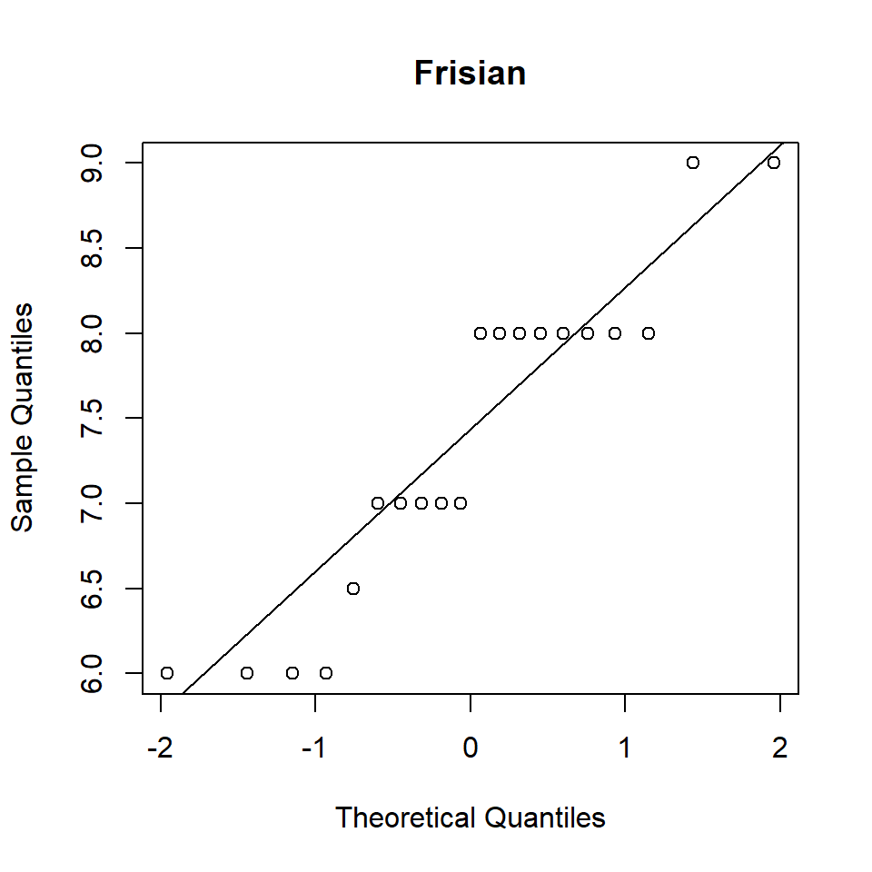

```r
qqnorm(full[full$spk_frisian == "Y",]$english_grade, main = 'Frisian')
qqline(full[full$spk_frisian == "Y",]$english_grade)
```

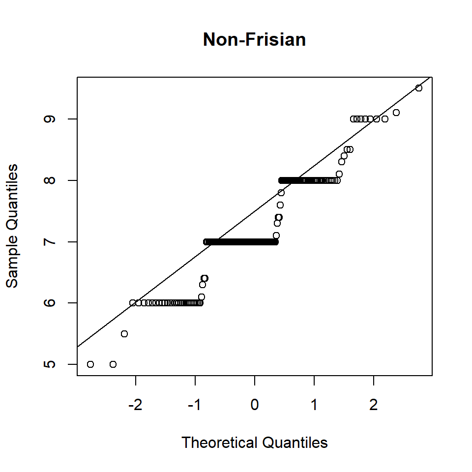

```r
qqnorm(full[full$spk_frisian == "N",]$english_grade, main = 'Non-Frisian')
qqline(full[full$spk_frisian == "N",]$english_grade)
```

```r
shapiro.test(full[full$spk_frisian == "Y",]$english_grade)
```

```
##
##  Shapiro-Wilk normality test
##
## data:  full[full$spk_frisian == "Y", ]$english_grade
## W = 0.88524, p-value = 0.02201
```

```r
shapiro.test(full[full$spk_frisian == "N",]$english_grade)
```

```
##
##  Shapiro-Wilk normality test
##
## data:  full[full$spk_frisian == "N", ]$english_grade
## W = 0.90857, p-value = 5.764e-09
```

```r
wilcox.test(full[full$spk_frisian == "Y",]$english_grade, full[full$spk_frisian == "N",]$english_grade, alternative = "greater")
```

```
##
##  Wilcoxon rank sum test with continuity correction
##
## data:  full[full$spk_frisian == "Y", ]$english_grade and full[full$spk_frisian == "N", ]$english_grade
## W = 1931, p-value = 0.2138
## alternative hypothesis: true location shift is greater than 0
```

```r
cliff.delta(full[full$spk_frisian == "Y",]$english_grade, full[full$spk_frisian == "N",]$english_grade)
```

```
##
## Cliff's Delta
##
## delta estimate: 0.1034286 (negligible)
## 95 percent confidence interval:
##        inf        sup
## -0.1777878  0.3690276
```

In this excercise will try to answer the following question:

Is the English grade of people who speak Frisian higher than those who do not?

We will look at the English grade to determine if it is higher for the Frisian speaking students than the English grade of non-Frisian speaking students. The sample exsists out of 195 students from the university of Groningen who follow the Statistics 1 course at the faculty of Arts who filled in a questionnaire from which the data was extracted.

$H_0$: The English grade of Frisian speaking students are the same as the English grade of non-Frisian speaking students. $H_a$: The English grade of Frisian speaking students are higher than the English grade of non-Frisian speaking students.

$H_0$: $\mu_y$ = $\mu_n$ $H_a$: $\mu_y$ > $\mu_n$

$\alpha$ = 0.05

We use the Mann-Whitney U test because we use numerical data which can be measured in ratio, do not know the standard deviation, the groups are not normally distributed and one of the groups is below the sample minimum size of 30.

p-value = 0.2138 U-value = 1931 delta estimate: 0.1034286 (negligible)

The p-value is higher than the significance level of 0.05 and therefor we do not reject $H_0$.

# 4 Exercise 4

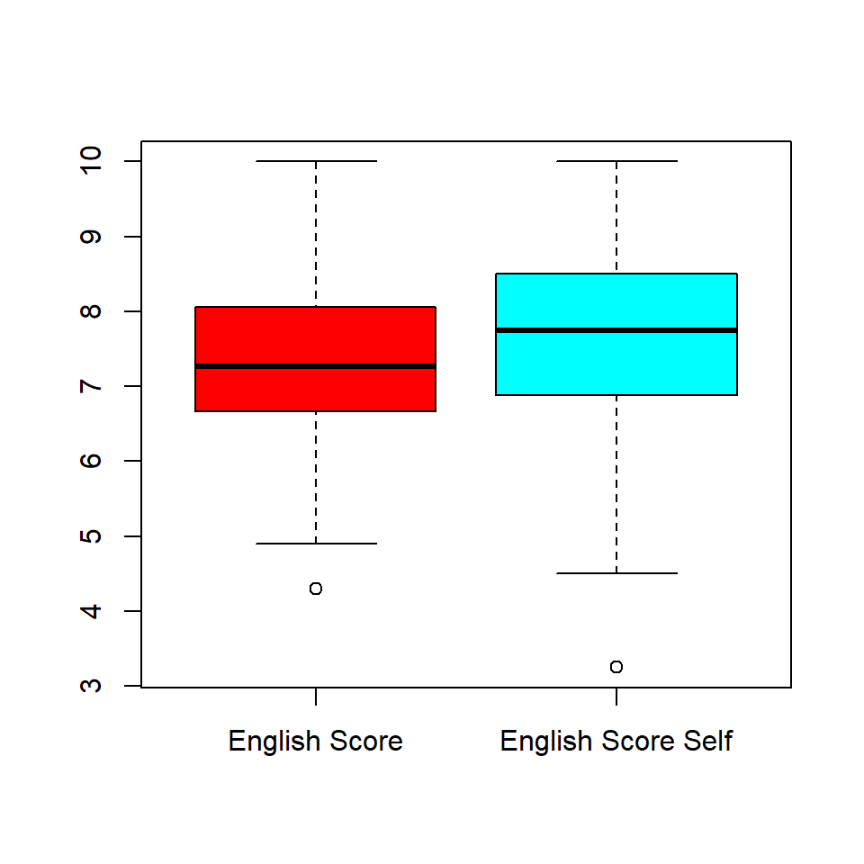

```r
boxplot(full$english_score, full$english_score_self, names = c("English Score","English Score Self"), col=rainbow(2))
```

```r
mean(full$english_score)
```

```
## [1] 7.326644
```

```r
mean(full$english_score_self)
```

```
## [1] 7.608974
```

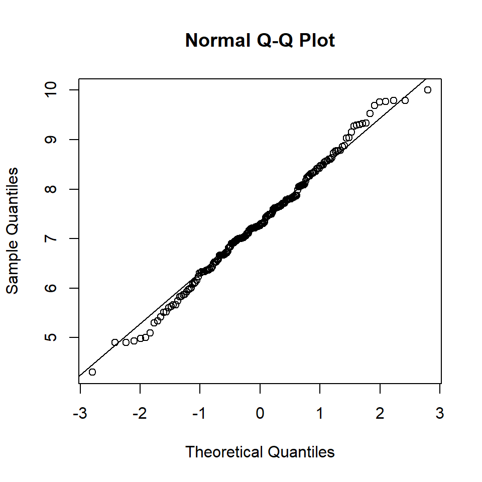

```r
qqnorm(full$english_score)
qqline(full$english_score)
```

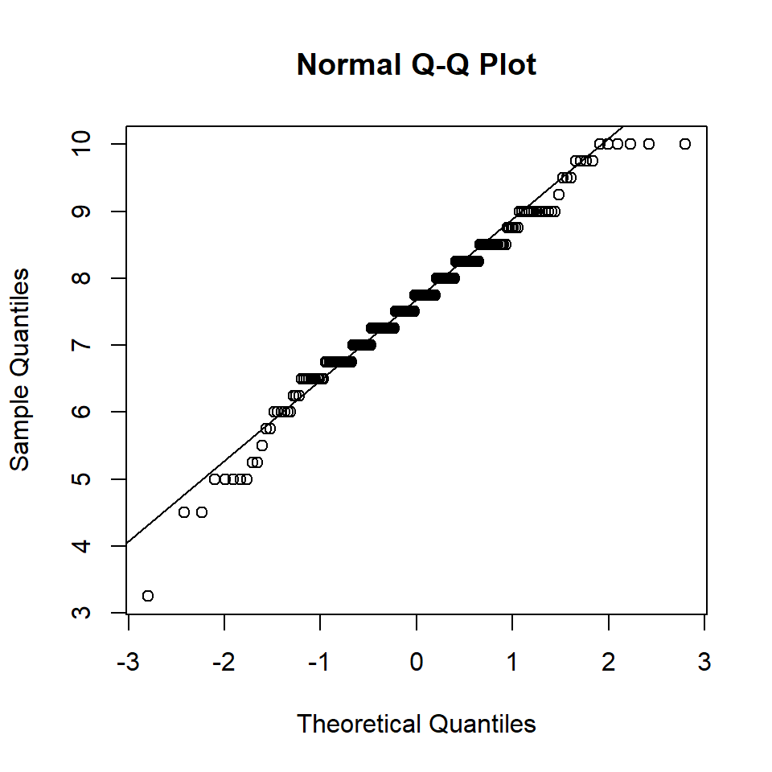

```r
qqnorm(full$english_score_self)
qqline(full$english_score_self)
```

```r
t.test(full$english_score, full$english_score_self, paired = TRUE)
```

```
##
##  Paired t-test
##
## data:  full$english_score and full$english_score_self
## t = -6.1371, df = 194, p-value = 4.642e-09
## alternative hypothesis: true difference in means is not equal to 0
## 95 percent confidence interval:
##  -0.3730624 -0.1915987
## sample estimates:
## mean of the differences
##              -0.2823305
```

```r
cohen.d(full$english_score, full$english_score_self)
```

```
##
## Cohen's d
##
## d estimate: -0.2453474 (small)
## 95 percent confidence interval:
##         inf         sup
## -0.44520950 -0.04548535
```

In this excercise will try to answer the following question:

What is the relation between english_score and english_score_self?

We will look at the English score and the self predicted English score of one sample group. The sample exsists out of 195 students from the university of Groningen who follow the Statistics 1 course at the faculty of Arts who filled in a questionnaire from which the data was extracted. We are going to look if there is a difference between the English score and the self predicted English score of the students.

$H_0$: The English score is the same as the self predicted English score. $H_a$: The English score is different than the self predicted English score.

$H_0$: $\mu_e$ = $\mu_s$ $H_a$: $\mu_e$ $\neq$ $\mu_s$

$\alpha$ = 0.05

Results:

t = -6.1371 df = 194 p-value = 4.642e-09 confidence interval = -0.3730624, -0.1915987 mean of the differences = -0.2823305 cohens d estimate = -0.2453474 (small)

The p-value is lower than the significance level of 0.05 and therefor we do reject $H_0$ and accept $H_a$.

The effectsize is -0.2453474 (small)

Conlusion:

The English score is different from the self predicted English score. The p-value is far below the significance level which means the students mis predicted their own English scores. The effectsizze is small but noticable. Even though we must accept $H_a$ the effectsize isn’t that high and could be disregarded.

# 5 Exercise 5

```r
SATSdifficulty <- full[,c("Q6", "Q8", "Q22", "Q24", "Q30", "Q34", "Q36")]
SATSvalue <- full[,c("Q7", "Q9", "Q10", "Q13", "Q16", "Q17", "Q21", "Q25", "Q33")]
alpha(SATSdifficulty)
```

```
## Some items ( Q6 Q22 ) were negatively correlated with the total scale and
## probably should be reversed.
## To do this, run the function again with the 'check.keys=TRUE' option
```

```
##
## Reliability analysis
## Call: alpha(x = SATSdifficulty)
##
##   raw_alpha std.alpha G6(smc) average_r  S/N   ase mean   sd
##       0.11      0.21    0.45     0.037 0.27 0.094  4.3 0.47
##
##  lower alpha upper     95% confidence boundaries
## -0.07 0.11 0.3
##
##  Reliability if an item is dropped:
##     raw_alpha std.alpha G6(smc) average_r     S/N alpha se
## Q6      0.543    0.5210    0.59    0.1534  1.0875    0.046
## Q8     -0.075    0.0294    0.25    0.0050  0.0303    0.123
## Q22     0.321    0.4413    0.58    0.1163  0.7899    0.070
## Q24    -0.123    0.0152    0.31    0.0026  0.0154    0.127
## Q30    -0.145   -0.0221    0.33   -0.0036 -0.0216    0.128
## Q34    -0.149   -0.0066    0.33   -0.0011 -0.0066    0.130
## Q36    -0.173   -0.0667    0.30   -0.0105 -0.0625    0.130
##
##  Item statistics
##       n  raw.r  std.r r.cor r.drop mean  sd
## Q6  195 -0.115 -0.176 -0.54  -0.49  3.4 1.4
## Q8  195  0.573  0.584  0.65   0.22  5.1 1.3
## Q22 195  0.014  0.014 -0.37  -0.29  3.6 1.1
## Q24 195  0.592  0.597  0.56   0.29  5.1 1.1
## Q30 195  0.608  0.629  0.53   0.33  4.2 1.1
## Q34 195  0.615  0.616  0.54   0.30  4.3 1.2
## Q36 195  0.632  0.664  0.60   0.39  4.4 1.0
##
## Non missing response frequency for each item
##        1    2    3    4    5    6    7 miss
## Q6  0.09 0.22 0.16 0.31 0.13 0.08 0.01    0
## Q8  0.01 0.05 0.07 0.13 0.29 0.36 0.09    0
## Q22 0.01 0.18 0.22 0.45 0.10 0.04 0.00    0
## Q24 0.00 0.03 0.04 0.23 0.28 0.36 0.06    0
## Q30 0.00 0.08 0.09 0.51 0.17 0.13 0.02    0
## Q34 0.01 0.07 0.16 0.34 0.27 0.12 0.03    0
## Q36 0.01 0.04 0.06 0.50 0.24 0.15 0.01    0
```

```r
alpha(SATSvalue)
```

```
## Some items ( Q9 Q10 Q17 ) were negatively correlated with the total scale and
## probably should be reversed.
## To do this, run the function again with the 'check.keys=TRUE' option
```

```
##
## Reliability analysis
## Call: alpha(x = SATSvalue)
##
##   raw_alpha std.alpha G6(smc) average_r    S/N  ase mean   sd
##      -0.11    -0.055    0.28   -0.0058 -0.052 0.12  3.5 0.39
##
##  lower alpha upper     95% confidence boundaries
## -0.34 -0.11 0.12
##
##  Reliability if an item is dropped:
##     raw_alpha std.alpha G6(smc) average_r   S/N alpha se
## Q7      -0.29     -0.28    0.13    -0.028 -0.22    0.140
## Q9       0.14      0.19    0.42     0.028  0.23    0.086
## Q10      0.16      0.25    0.44     0.039  0.33    0.085
## Q13     -0.35     -0.30    0.13    -0.029 -0.23    0.148
## Q16     -0.23     -0.19    0.19    -0.021 -0.16    0.135
## Q17      0.24      0.23    0.44     0.037  0.30    0.078
## Q21     -0.20     -0.14    0.26    -0.015 -0.12    0.130
## Q25     -0.38     -0.31    0.13    -0.030 -0.23    0.152
## Q33     -0.37     -0.33    0.06    -0.032 -0.25    0.150
##
##  Item statistics
##       n  raw.r   std.r r.cor r.drop mean   sd
## Q7  195  0.478  0.5400  0.59  0.227  2.1 0.96
## Q9  195  0.039  0.0039 -0.43 -0.309  5.2 1.27
## Q10 195 -0.091 -0.1070 -0.57 -0.380  5.2 1.11
## Q13 195  0.539  0.5522  0.57  0.218  2.7 1.23
## Q16 195  0.445  0.4665  0.43  0.112  3.3 1.20
## Q17 195 -0.038 -0.0791 -0.59 -0.397  3.5 1.38
## Q21 195  0.434  0.4155  0.21  0.064  3.5 1.32
## Q25 195  0.564  0.5593  0.59  0.227  2.9 1.30
## Q33 195  0.549  0.5785  0.76  0.248  3.0 1.17
##
## Non missing response frequency for each item
##        1    2    3    4    5    6    7 miss
## Q7  0.28 0.49 0.12 0.11 0.01 0.00 0.00    0
## Q9  0.01 0.05 0.04 0.13 0.30 0.37 0.10    0
## Q10 0.01 0.02 0.04 0.20 0.23 0.44 0.07    0
## Q13 0.12 0.46 0.19 0.14 0.06 0.04 0.00    0
## Q16 0.03 0.26 0.25 0.30 0.10 0.05 0.00    0
## Q17 0.07 0.21 0.17 0.29 0.19 0.06 0.01    0
## Q21 0.04 0.23 0.23 0.29 0.14 0.06 0.01    0
## Q25 0.10 0.37 0.21 0.21 0.07 0.04 0.01    0
## Q33 0.04 0.38 0.26 0.19 0.09 0.03 0.00    0
```

```r
full$SATSvalue <- ((8-full$Q7)+full$Q9 + full$Q10 + (8-full$Q13) + (8-full$Q16) + full$Q17 + (8-full$Q21) + (8-full$Q25) + (8-full$Q33))/7
full$SATSdifficulty <- (full$Q6 + (8-full$Q8) + full$Q22 + (8-full$Q24) + (8-full$Q30) + (8-full$Q34) + (8-full$Q36))/7
head(full)
```

```
##   participant study edu_level gender hand instrument bl_edu l1cnt l2cnt
## 1           1  LING       VWO      F    R          Y      N     1     2
## 2          10 OTHER      HAVO      F    R          Y      N     2     2
## 3         100   CIS       VWO      F    R          N      N     1     2
## 4         101  LING       VWO      F    R          Y      N     1     1
## 5         102    IS       VWO      M    R          Y      N     1     1
## 6         103   CIS      HAVO      F    R          N      Y     1     1
##   age_listening age_reading age_speaking age_writing accent_strength_self
## 1             5          10           12          12                    5
## 2             7           7            7           7                    4
## 3            12          10           11          10                    6
## 4            10          10           10          10                    4
## 5            11          11           13          12                    8
## 6             9          10           10          10                    5
##   english_grade english_score_self english_score spk_frisian Q1 Q2 Q3 Q4
```

[output cut: 27 more lines]

```r
cor(full$SATSvalue, full$SATSdifficulty, use = "pairwise.complete.obs")
```

```
## [1] 0.2211525
```

Because the SATSdifficulty and SATSvalue are both lower than 0.7 we can state that the reliability is not acceptable. The Raw alpha is 0.11 and -0.11. In SATSdifficulty, Q6 and Q22 should be dropped and in SATSvalue, Q9 Q10 Q17.  
The correlation between SATSvalue and SATSdifficulty is 0.2211525.

# 6 Excercise 6

```r
class(full$english_score)
```

```
## [1] "numeric"
```

```r
table(full$spk_frisian)
```

```
##
##   Y   N
##  20 175
```

```r
frisian <- full[full$spk_frisian == "Y",]
non_frisian <- full[full$spk_frisian == "N",]
mean(frisian$english_score)
```

```
## [1] 7.683504
```

```r
mean(non_frisian$english_score)
```

```
## [1] 7.28586
```

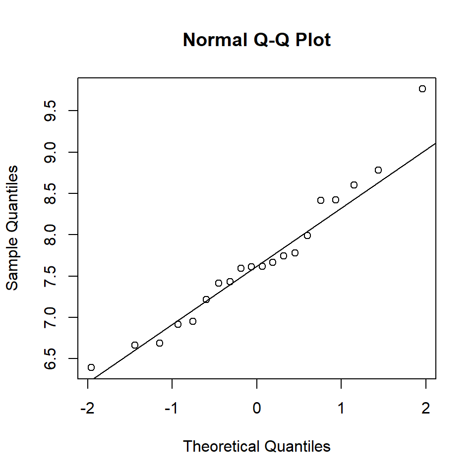

```r
qqnorm(frisian$english_score)
qqline(frisian$english_score)
```

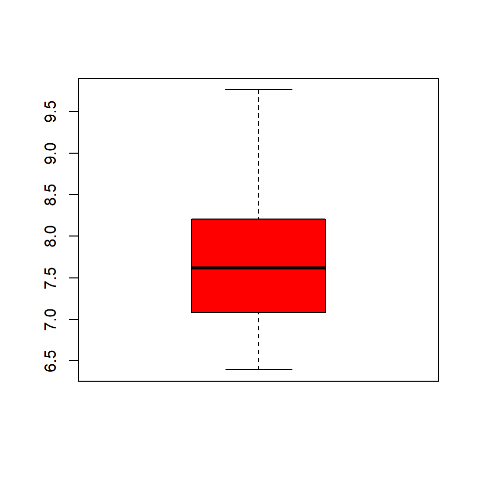

```r
boxplot(frisian$english_score, col="red")
```

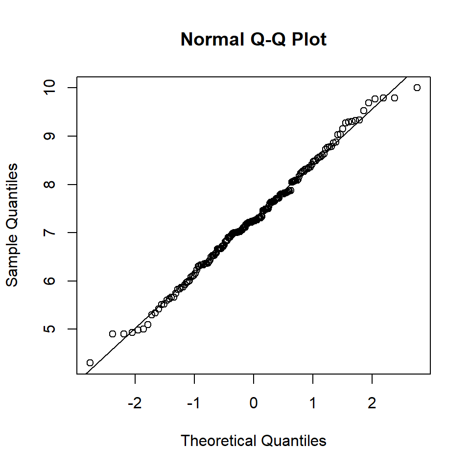

```r
qqnorm(non_frisian$english_score)
qqline(non_frisian$english_score)
```

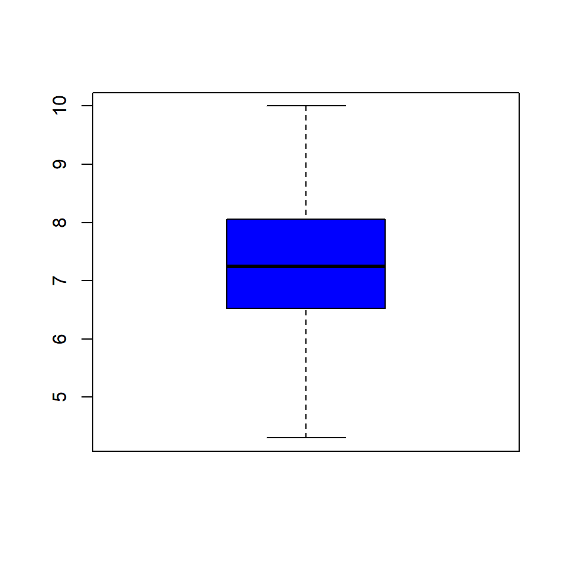

```r
boxplot(non_frisian$english_score, col="blue")
```

```r
shapiro.test(frisian$english_score)
```

```
##
##  Shapiro-Wilk normality test
##
## data:  frisian$english_score
## W = 0.95613, p-value = 0.4697
```

```r
shapiro.test(non_frisian$english_score)
```

```
##
##  Shapiro-Wilk normality test
##
## data:  non_frisian$english_score
## W = 0.99427, p-value = 0.7329
```

```r
t.test(frisian$english_score, non_frisian$english_score, mu=0, alt="two.sided", conf=0.95, var.eq=F, paired=F)
```

```
##
##  Welch Two Sample t-test
##
## data:  frisian$english_score and non_frisian$english_score
## t = 1.9642, df = 28.2, p-value = 0.05943
## alternative hypothesis: true difference in means is not equal to 0
## 95 percent confidence interval:
##  -0.0169102  0.8121976
## sample estimates:
## mean of x mean of y
##  7.683504  7.285860
```

```r
cohen.d(frisian$english_score, non_frisian$english_score)
```

```
##
## Cohen's d
##
## d estimate: 0.3572748 (small)
## 95 percent confidence interval:
##        inf        sup
## -0.1096373  0.8241869
```

In this excercise will try to answer the following question:

Is the English score of people who speak Frisian different from those who do not?

We will look at the means of both the Frisian and non-Frisian speakers english_score. The Frisian speakers exists out of 20 students and the non-Frisian speakers out of 175 students from the university of Groningen who follow the Statistics 1 course at the faculty of Arts who filled in a questionnaire from which the data was extracted. We are going to look if there is a differnce between the English scores of the Frisian speakers and the non-Frisian speakers.

$H_0$: The english score of Frisian speakers is the same as the english score of non-Frisian speakers. $H_a$: The english score of Frisian speakers is different from the english score of non-Frisian speakers.

$H_0$: $\mu$fr = $\mu$non $H_a$: $\mu$fr $\neq$ $\mu$non

$\alpha$ = 0.05

We use a two sided sample independent t-test because we want to compare two independent samples without knowing the standard deviation and where the arguments are numerical. The qqplot determines that the distribution is close to normal and the Shapiro-Wilk test p-values are both above the significance level of 0.05 which means the samples do not deviate from normality.

Results:

The p-value is higher than the significance level of 0.05 and therefor we do not reject $H_0$.

The effectsize is 0.3572748 (small).

Conlusion:

There is no difference between the Frisian and the non-Frisian speakers when it comes to english_scores. Although I must say it was rather close to the significance level the effectsize also remains smalls. This means it couldn’t be noticed with the naked eyes and therefor I must conclude that there isn’t a significant difference between $H_0$ and $H_a$.

# 7 Excercise 7

```r
class(full$age_reading)
```

```
## [1] "numeric"
```

```r
class(full$age_speaking)
```

```
## [1] "numeric"
```

```r
(mean_ar <- mean(full$age_reading))
```

```
## [1] 9.764103
```

```r
(mean_as <- mean(full$age_speaking))
```

```
## [1] 9.974359
```

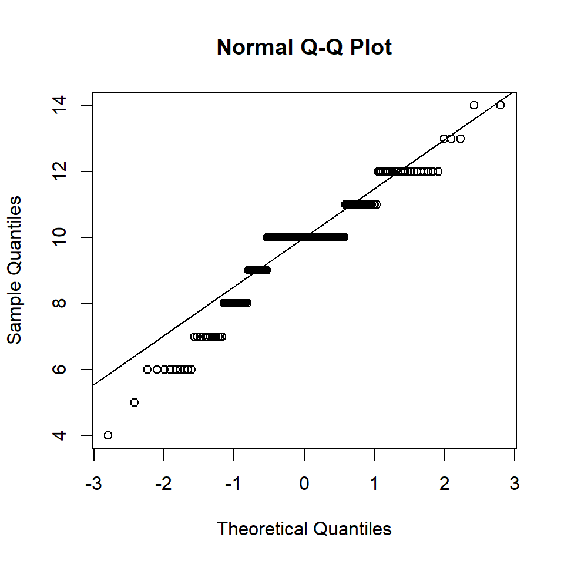

```r
qqnorm(full$age_reading)
qqline(full$age_reading)
```

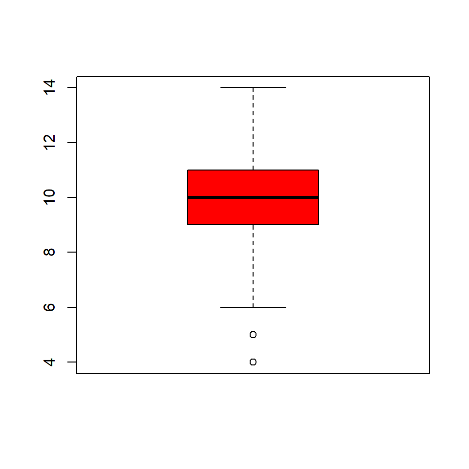

```r
boxplot(full$age_reading, col="red")
```

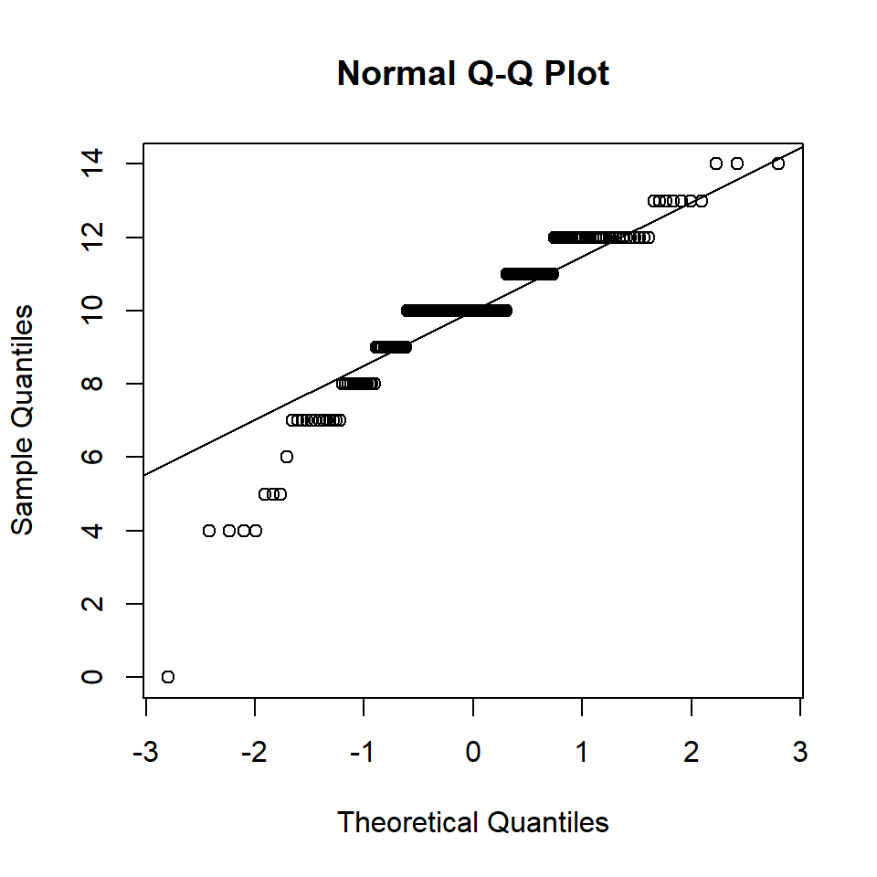

```r
qqnorm(full$age_speaking)
qqline(full$age_speaking)
```

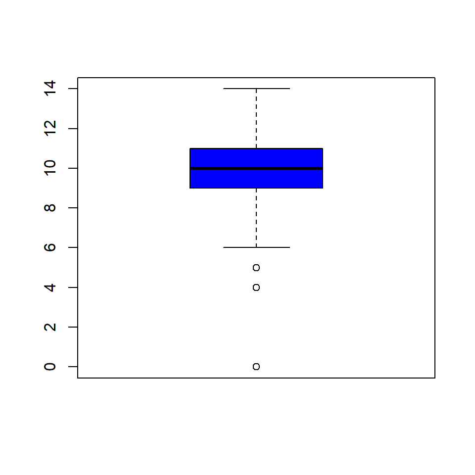

```r
boxplot(full$age_speaking, col="blue")
```

```r
shapiro.test(full$age_reading)
```

```
##
##  Shapiro-Wilk normality test
##
## data:  full$age_reading
## W = 0.92141, p-value = 1.036e-08
```

```r
shapiro.test(full$age_speaking)
```

```
##
##  Shapiro-Wilk normality test
##
## data:  full$age_speaking
## W = 0.89665, p-value = 2.254e-10
```

```r
t.test(full$age_reading, full$age_speaking, mu=0, alt="less", conf=0.95, var.eq=F, paired=T)
```

```
##
##  Paired t-test
##
## data:  full$age_reading and full$age_speaking
## t = -1.8977, df = 194, p-value = 0.02961
## alternative hypothesis: true difference in means is less than 0
## 95 percent confidence interval:
##         -Inf -0.02714119
## sample estimates:
## mean of the differences
##              -0.2102564
```

```r
cohen.d(full$age_reading, full$age_speaking)
```

```
##
## Cohen's d
##
## d estimate: -0.1114058 (negligible)
## 95 percent confidence interval:
##         inf         sup
## -0.31067458  0.08786295
```

In this excercise will try to answer the following question:

Is the average age when people learn how to read English lower than the average age when people learn how to speak English?

We will look at the average age of reading English and the average age of learning how to speak English of one sample group. The sample exsists out of 195 students from the university of Groningen who follow the Statistics 1 course at the faculty of Arts who filled in a questionnaire from which the data was extracted. We are going to look if the the average age of reading English is lower than the average age of speaking English.

$H_0$: The average age of reading English is the same as the average age of speaking English. $H_a$: The average age of reading English is lower than the average age of speaking English.

$H_0$: $\mu$r = $\mu$s $H_a$: $\mu$r < $\mu$s

$\alpha$ = 0.05

We use a one sided paired sample t-test because we want to determine if one set of data is lower than the other set of data of the same sample without knowing the standard deviation and where the arguments are numerical and can be measured in ratio. The qqplot determines that the distribution is is not close to normal and the Shapiro-Wilk test p-values are both below the significance level of 0.05 which means the samples do deviate from normality but because the sample size is above 30 the paired sample t-test can still be used.

Results:

t = -1.8977 df = 194 p-value = 0.02961 confidence interval = -0.02714119 mean of the differences = -0.2102564 cohens d estimate = -0.1114058 (negligible)

The p-value is lower than the significance level of 0.05 and therefor we do reject $H_0$ and accept $H_a$.

The effectsize is -0.1114058 (negligible)

Conlusion:

The age of reading English is lower than the age of speaking English in this sample. Even the effectsize negligible. This means it couldn’t be noticed with the naked eyes. Even though we must accept $H_a$ the effectsize isn’t that high and could be disregarded.

# 8 Excercise 8

```r
class(full$handedness)
```

```
## [1] "NULL"
```

```r
class(full$gender)
```

```
## [1] "factor"
```

```r
table(full$bl_edu)
```

```
##
##   Y   N
##  19 176
```

```r
mono_edu <- full[full$bl_edu == "N",]
(tbl <- table(mono_edu$hand, mono_edu$gender))
```

```
##
##       F   M
##   R 117  38
##   L  13   8
```

```r
round(chisq.test(tbl)$expected)
```

```
##
##       F  M
##   R 114 41
##   L  16  5
```

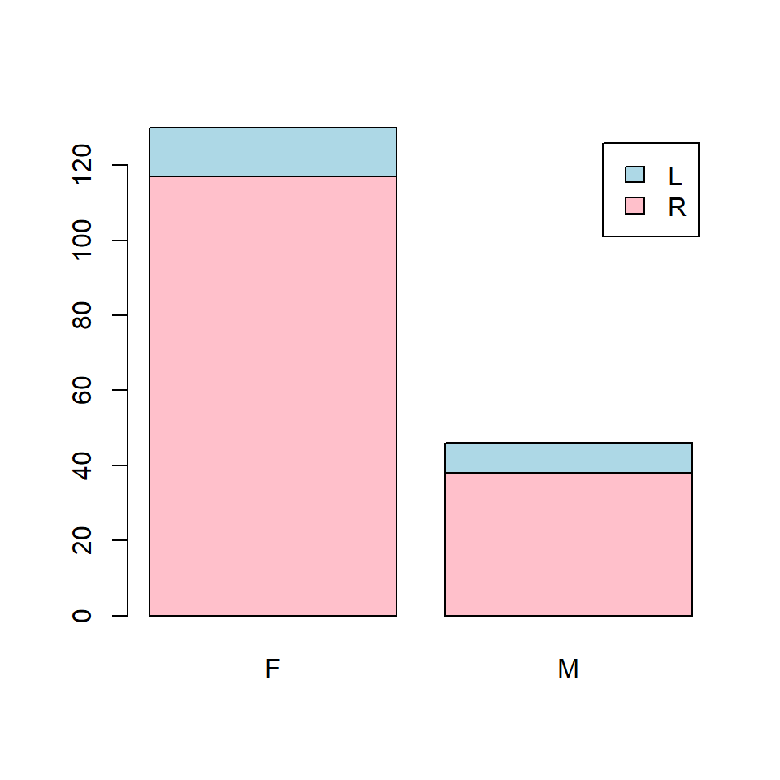

```r
barplot(tbl, legend = c("R", "L"), col = c("pink", "lightblue"))
```

```r
chisq.test(tbl, correct=FALSE)
```

```
##
##  Pearson's Chi-squared test
##
## data:  tbl
## X-squared = 1.7665, df = 1, p-value = 0.1838
```

```r
assocstats(tbl)
```

```
##                     X^2 df P(> X^2)
## Likelihood Ratio 1.6497  1  0.19900
## Pearson          1.7665  1  0.18382
##
## Phi-Coefficient   : 0.1
## Contingency Coeff.: 0.1
## Cramer's V        : 0.1
```

```r
chisq.test(tbl)$observed
```

```
##
##       F   M
##   R 117  38
##   L  13   8
```

```r
prop.table(tbl, 2)
```

```
##
##            F        M
##   R 0.900000 0.826087
##   L 0.100000 0.173913
```

```r
prop.table(tbl, 1)
```

```
##
##             F         M
##   R 0.7548387 0.2451613
##   L 0.6190476 0.3809524
```

```r
chisq.test(tbl)$stdres  # z-scored differences
```

```
##
##             F         M
##   R  1.329084 -1.329084
##   L -1.329084  1.329084
```

In this excercise will try to answer the following question:

Is there a relationship between handedness and gender for students who had monolingual education?

We will look at the handedness(2 levels: L, R) and gender (2 levels: F, M) of students who had a monolingual education. The sample exsists out of 176 students from the university of Groningen who follow the Statistics 1 course at the faculty of Arts who filled in a questionnaire from which the data was extracted. We are going to look if handedness and the gender of the monolingual students are dependend.

$H_0$: Handedness and gender for students with a monolinual education are independent. $H_a$: Handedness and gender for students with a monolingual education are dependent.

$\alpha$ = 0.05

The table shows their relation. As both variables are nominal, and the expected frequency of each combination was equal or greater than 5, we assessed the dependence of the two variables using the Chi Squared test.

X-squared = 1.7665 df = 1 p-value = 0.1838  
Cramer’s V = 0.1

The p-value is higher than the significance level of 0.05 and therefor we do not reject $H_0$.

# 9 Excercise 9

```r
class(full$english_grade)
```

```
## [1] "numeric"
```

```r
table(full$spk_frisian)
```

```
##
##   Y   N
##  20 175
```

```r
frisian <- full[full$spk_frisian == "Y",]
non_frisian <- full[full$spk_frisian == "N",]
mean(frisian$english_grade)
```

```
## [1] 7.375
```

```r
mean(non_frisian$english_grade)
```

```
## [1] 7.192571
```

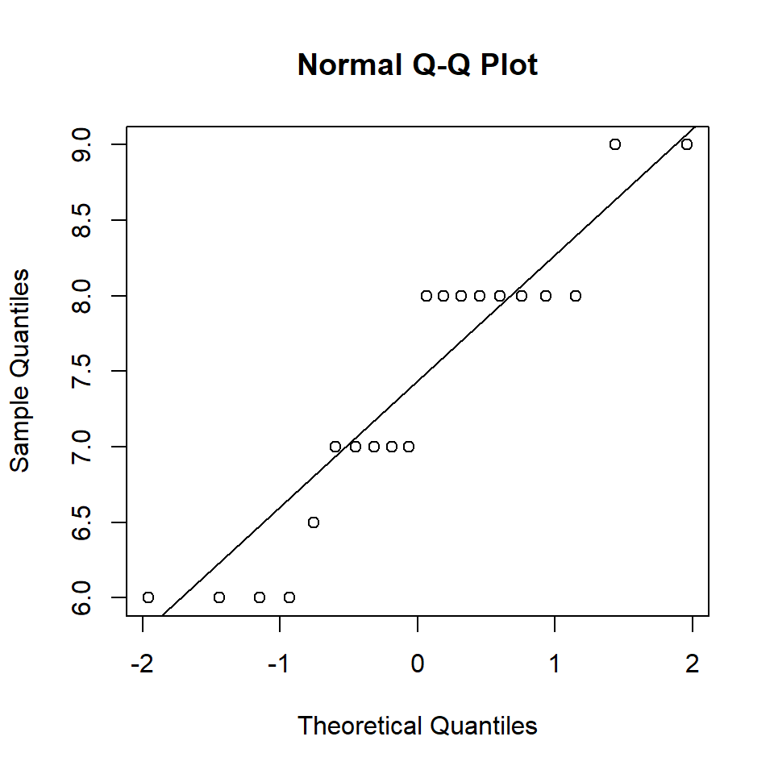

```r
qqnorm(frisian$english_grade)
qqline(frisian$english_grade)
```

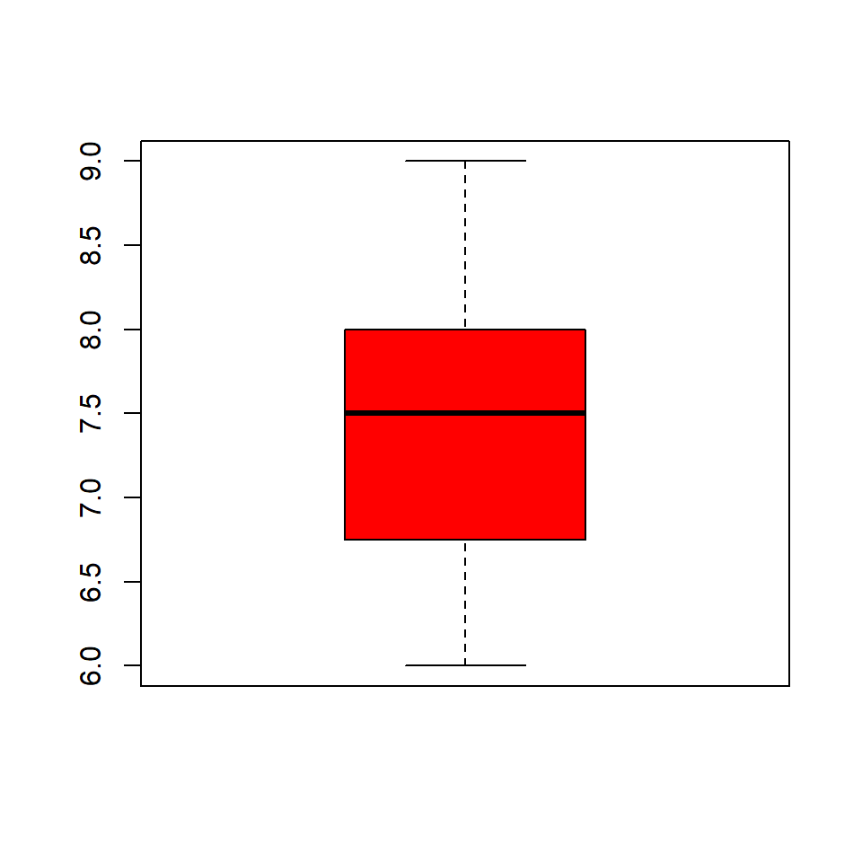

```r
boxplot(frisian$english_grade, col="red")
```

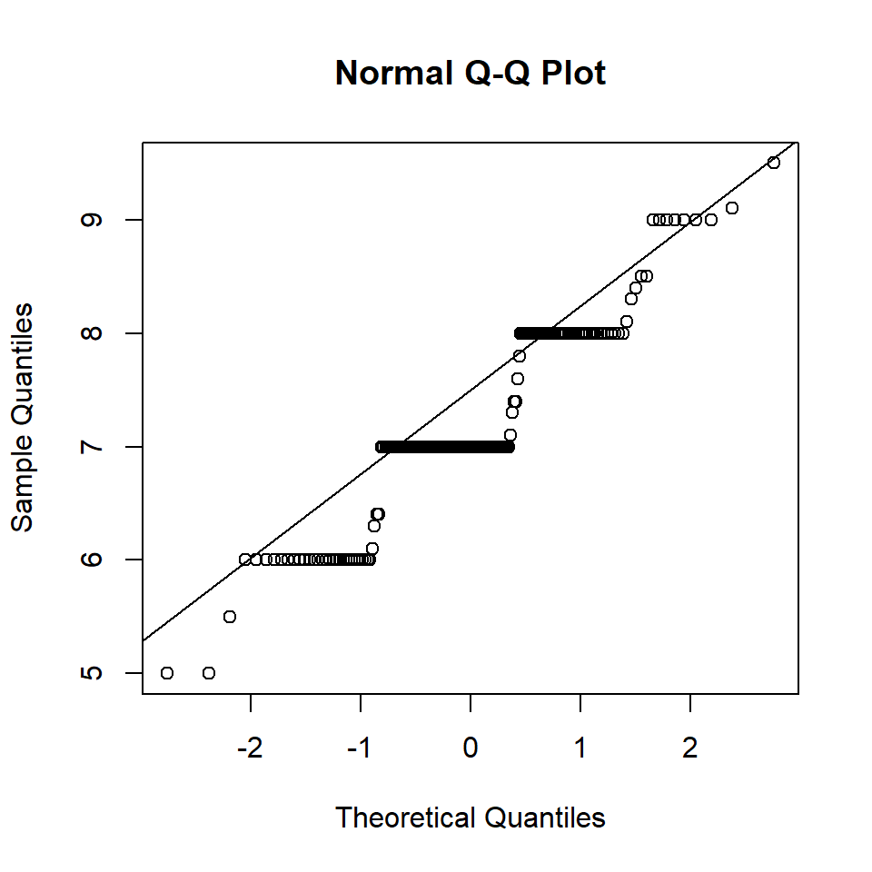

```r
qqnorm(non_frisian$english_grade)
qqline(non_frisian$english_grade)
```

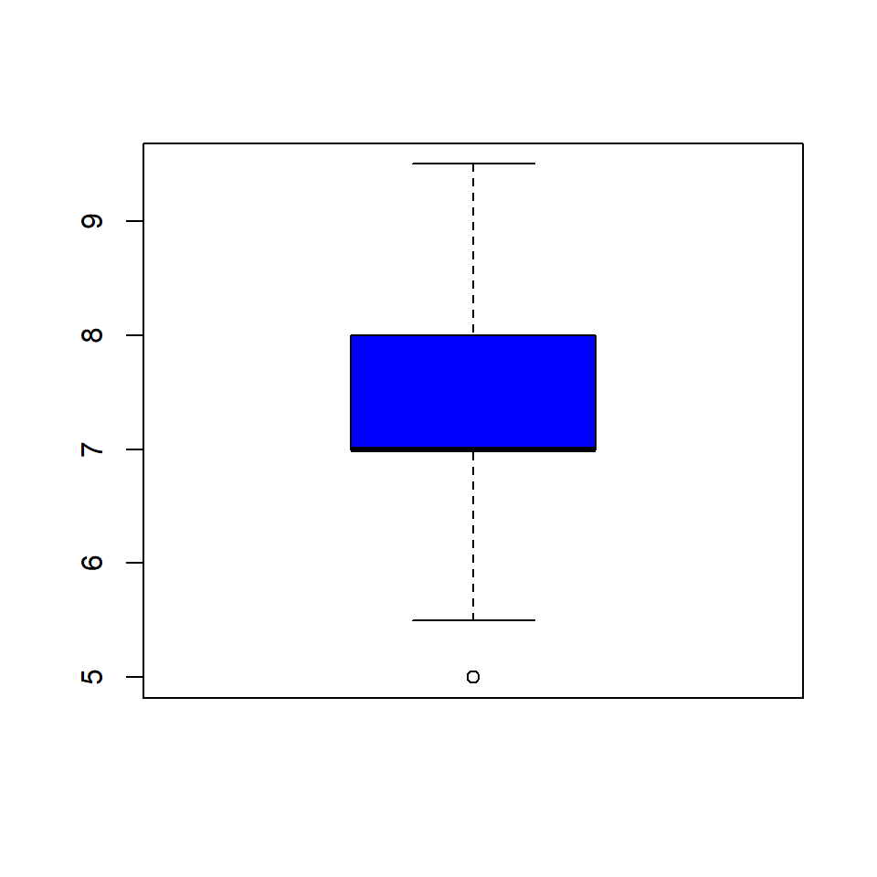

```r
boxplot(non_frisian$english_grade, col="blue")
```

```r
shapiro.test(frisian$english_grade)
```

```
##
##  Shapiro-Wilk normality test
##
## data:  frisian$english_grade
## W = 0.88524, p-value = 0.02201
```

```r
shapiro.test(non_frisian$english_grade)
```

```
##
##  Shapiro-Wilk normality test
##
## data:  non_frisian$english_grade
## W = 0.90857, p-value = 5.764e-09
```

```r
t.test(frisian$english_grade, non_frisian$english_grade, mu=0, alt="two.sided", conf=0.95, var.eq=F, paired=F)
```

```
##
##  Welch Two Sample t-test
##
## data:  frisian$english_grade and non_frisian$english_grade
## t = 0.81531, df = 22.597, p-value = 0.4234
## alternative hypothesis: true difference in means is not equal to 0
## 95 percent confidence interval:
##  -0.2809007  0.6457578
## sample estimates:
## mean of x mean of y
##  7.375000  7.192571
```

```r
cohen.d(frisian$english_grade, non_frisian$english_grade)
```

```
##
## Cohen's d
##
## d estimate: 0.2107175 (small)
## 95 percent confidence interval:
##        inf        sup
## -0.2553046  0.6767396
```

In this excercise will try to answer the following question:

Is the English grade of people who speak Frisian different from those who do not?

We will look at the means of both the Frisian and non-Frisian speakers english_grade. The Frisian speakers exists out of 20 students and the non-Frisian speakers out of 175 students from the university of Groningen who follow the Statistics 1 course at the faculty of Arts who filled in a questionnaire from which the data was extracted. We are going to look if there is a differnce between the English grades of the Frisian speakers and the non-Frisian speakers.

$H_0$: The english grade of Frisian speakers is the same as the english grade of non-Frisian speakers. $H_a$: The english grade of Frisian speakers is different from the english grade of non-Frisian speakers.

$H_0$: $\mu$fr = $\mu$non $H_a$: $\mu$fr $\neq$ $\mu$non

$\alpha$ = 0.05

Results:

The p-value is higher than the significance level of 0.05 and therefor we do not reject $H_0$.

The effectsize is 0.2107175 (small)

# 10 Exercise 10

```r
table(full$spk_frisian)
```

```
##
##   Y   N
##  20 175
```

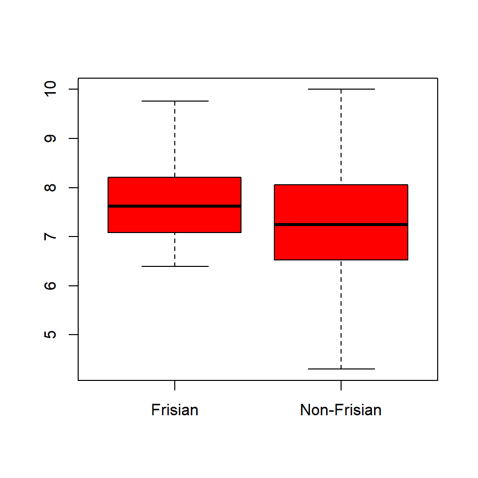

```r
boxplot(full[full$spk_frisian == "Y",]$english_score, full[full$spk_frisian == "N",]$english_score, names = c("Frisian","Non-Frisian"), col="red")
```

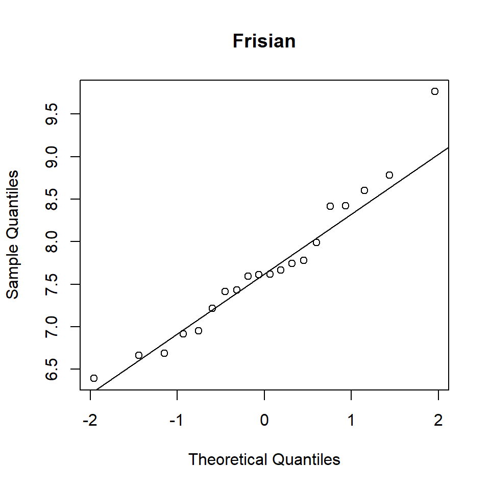

```r
qqnorm(full[full$spk_frisian == "Y",]$english_score, main = 'Frisian')
qqline(full[full$spk_frisian == "Y",]$english_score)
```

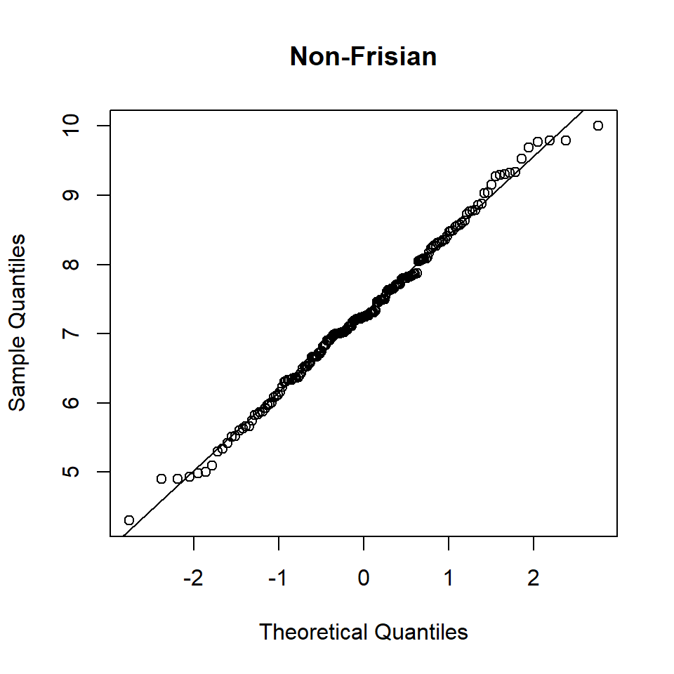

```r
qqnorm(full[full$spk_frisian == "N",]$english_score, main = 'Non-Frisian')
qqline(full[full$spk_frisian == "N",]$english_score)
```

```r
shapiro.test(full[full$spk_frisian == "Y",]$english_score)
```

```
##
##  Shapiro-Wilk normality test
##
## data:  full[full$spk_frisian == "Y", ]$english_score
## W = 0.95613, p-value = 0.4697
```

```r
shapiro.test(full[full$spk_frisian == "N",]$english_score)
```

```
##
##  Shapiro-Wilk normality test
##
## data:  full[full$spk_frisian == "N", ]$english_score
## W = 0.99427, p-value = 0.7329
```

```r
wilcox.test(full[full$spk_frisian == "Y",]$english_score, full[full$spk_frisian == "N",]$english_score, alternative = "greater")
```

```
##
##  Wilcoxon rank sum test with continuity correction
##
## data:  full[full$spk_frisian == "Y", ]$english_score and full[full$spk_frisian == "N", ]$english_score
## W = 2116, p-value = 0.06317
## alternative hypothesis: true location shift is greater than 0
```

```r
cliff.delta(full[full$spk_frisian == "Y",]$english_score, full[full$spk_frisian == "N",]$english_score)
```

```
##
## Cliff's Delta
##
## delta estimate: 0.2091429 (small)
## 95 percent confidence interval:
##         inf         sup
## -0.01335466  0.41190649
```

In this excercise will try to answer the following question:

Is the English score of people who speak Frisian higher than those who do not?

We will look at the English score to determine if it is higher for the Frisian speaking students than the English score of non-Frisian speaking students. The sample exsists out of 195 students from the university of Groningen who follow the Statistics 1 course at the faculty of Arts who filled in a questionnaire from which the data was extracted.

$H_0$: The English score of Frisian speaking students are the same as the English score of non-Frisian speaking students. $H_a$: The English score of Frisian speaking students are higher than the English score of non-Frisian speaking students.

$H_0$: $\mu_y$ = $\mu_n$ $H_a$: $\mu_y$ > $\mu_n$

$\alpha$ = 0.05

p-value = 0.06317 U-value = 2116 delta estimate: 0.2091429 (small)

The p-value is higher than the significance level of 0.05 and therefor we do not reject $H_0$.